# AN588 - Homework 2

Christian Mei

# Titis in the Mist…

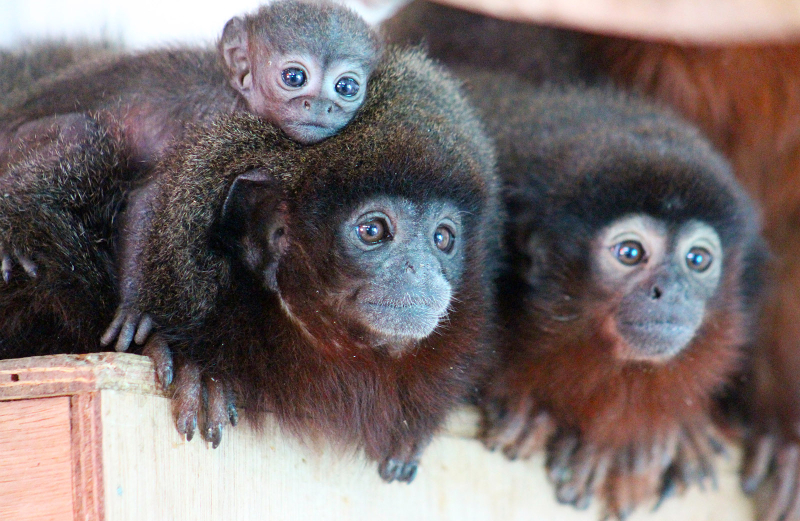

```r
knitr::include_graphics("images/clipboard-2053021673.png")
```

Every Saturday morning, at the same time, a primatologist goes and sits in the forest to listen for titi monkey calls, counting the number of calls they hear in a 2 hour window from 5am to 7am. Based on previous knowledge, she believes that the mean number of calls she will hear in that time is exactly 15. Let X represent the appropriate Poisson random variable of the number of calls heard in each monitoring session.

**Questions**

What is the probability that she will hear more than 8 calls during any given session?

What is the probability that she will hear no calls in a session?

What is the probability that she will hear exactly 3 calls in a session?

Plot the relevant Poisson mass function over the values in range 0 ≤ x ≤ 30.

Simulate 104 results from this distribution (i.e., 2 years of Saturday monitoring sessions).

Plot the simulated results using hist() and use xlim() to set the horizontal limits to be from 0 to 30. How does your histogram compare to the shape of the probability mass function you plotted above?

# Answer Attempt

I decided to answer the questions in the order I think felt more inuitive

## Plot the relevant Poisson mass function over the values in range 0 ≤ x ≤ 30

We first need to create the distribution/dataset that the primatologist collected before plotting it.

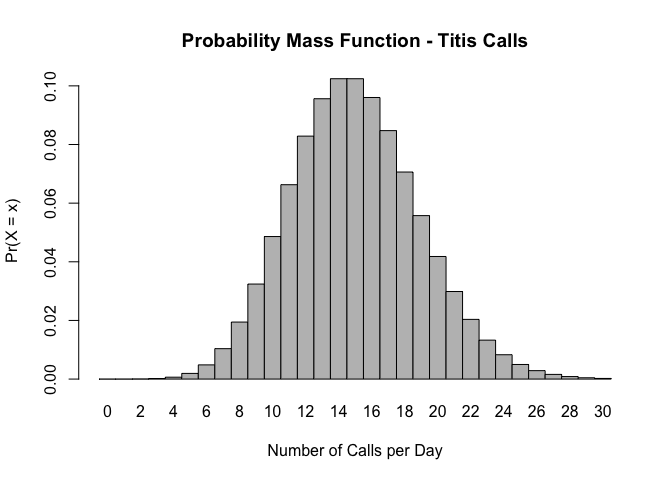

```r
call_ranges <- 0:30
l = 15 # Poisson mean lambda based on mean number of calls
titis_calls <- dpois(x = call_ranges, lambda = l)


barplot(titis_calls, names.arg = call_ranges, space = 0, xlab = "Number of Calls per Day", ylab = "Pr(X = x)", main = "Probability Mass Function - Titis Calls")
```

## Simulate 104 results from this distribution:

My initial attempt which resulted in a mistake. Why do you think this is the case? Why can’t I sample from the original `titis-calls` collection?

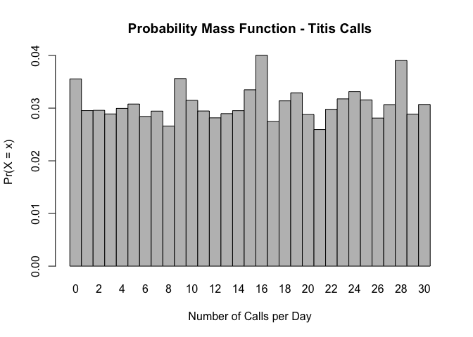

```r
sim <- NULL  # sets up a dummy variable to hold our 10000 simulations
n <- 104
for (i in 1:length(titis_calls)) {
    sim[i] <- mean(sample(titis_calls, n, replace = TRUE))
}

barplot(sim, names.arg = call_ranges, space = 0, xlab = "Number of Calls per Day", ylab = "Pr(X = x)", main = "Probability Mass Function - Titis Calls")
```

The problem above is that I am by sampling from `titis_calls` , I was sampling probability values and not data points (calls per day). Hence, this method is incorrect

What the assignment was actually asking for was to sample from a Poisson distribution with similar values, e.g same lambda mean = 15.

```r
set.seed(1) # So that everytime I run rpois, I get the same set of random numbers
simulated_calls <- rpois(104, lambda = l)
simulated_calls
```

```
##   [1] 12 20 19 16  9 16 17 17 13 20 16 12 13 13 15 11 18 17 18 18 15  7 16 19 12
##  [26] 13 16 20 14 16 14  9 18 13 19 13 21 17 13 11 12  8 17 14 18 16 12 11 20 22
##  [51] 13 10 10 24 14 17 15 12  9 20 15 23 16 12 14 17 19 15 14 11 12 19 17 14 13
##  [76] 13 18 13 19 17 20 11 19 17 21 17 10 15 18 18 11 11 10 21 17 18 16 21 12 15
## [101] 15  8 13 13
```

## Plot the simulated results using hist() and use xlim() to set the horizontal limits to be from 0 to 30.

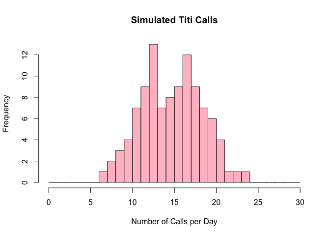

```r
hist(simulated_calls, breaks = 0:30, freq = TRUE, col = "pink",
     xlab = "Number of Calls per Day", main = "Simulated Titi Calls",
     xlim = c(0, 30))
```

## How does your histogram compare to the shape of the probability mass function you plotted above?

The two plots look quite different! The probability mass function looks more like a perfect bell curve whereas my version of the simulated histogram almost shows to have a bimodal distribution (2 peaks). But this may be because I don’t have enough data points. I think that if I have more than 104 samples, the data could look more like a normal distribution. We also need to keep in mind that these two graphs are showing very different things. The probability mass function graph plots the probabilities, not the individual data points (# of calls).

# Let’s answer the probability questions now!

## What is the probability that she will hear more than 8 calls during any given session?

```r
# ppois get equal or less than -> so we need to get the complement probability
# This means 1 - P(x =< 8)
more_than_8_calls <- 1 - ppois(8, l)
more_than_8_calls
```

```
## [1] 0.9625535
```

We can also plot the cumulative distribution function (CDF) to see the value in graphically!

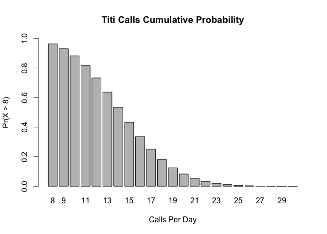

```r
barplot(1 - ppois(8:30, lambda = l), ylim = 0:1, names.arg = 8:30, xlab = "Calls Per Day",
    ylab = "Pr(X > 8)", main = "Titi Calls Cumulative Probability")
```

## What is the probability that she will hear no calls in a session?

```r
no_calls <- dpois(0, l)
no_calls
```

```
## [1] 3.059023e-07
```

## What is the probability that she will hear exactly 3 calls in a session?

```r
three_calls <- dpois(3, l)
three_calls
```

```
## [1] 0.0001720701
```

# Issues Encountered

1. I initially misunderstood what the sampling simulation meant. I the output of a `dpois()` function were not data points but rather probabilities. However I decided to keep my mistake in the assignment answer just to remind me in the future
2. Understanding what the differences between `dpois()` , `ppois()` , and `rpois()`
3. Completed the initial assignment on Quarto but needed to convert to RMarkdown to apply the `cayman` package